# Moje pasje

Od introwertyka do starosty na studiach…

# O mnie: Introwertyczny i ekstrawertyk

Jestem osobą, która najbardziej ceni sobie własne towarzystwo lub czas spędzony w zaufanym gronie.

**Moja natura**: Typowa introwertyczka.

**Paradoks**: W sytuacjach stresowych potrafię przybrać maskę ekstrawertyka.

*Gdzie czuję się najlepiej?*

- W domu z dobrą książką.
- Przy komputerze w świecie RPG.
- Słuchając mrocznych opowieści.

# Świat True Crime – Podcasty

Uwielbiam analizować mroczne zakamarki ludzkiej psychiki. Moja lista ulubionych twórców to fundament każdego wieczoru.

**Czego słucham najczęściej?**

1. Kryminatorium (klasyka gatunku)
2. Piąte, nie zabijaj (Justyna Mazur)
3. Olga Herring (seria True Crime)
4. RMF FM: Sceny zbrodni oraz Dorwać Bestię
5. MysteryTV: Straszne historie na dobranoc.

## Analiza słuchalności podcastów Uzasadnienie:

Wykres przedstawia mój subiektywny “wskaźnik zainteresowania” danymi seriami, co pokazuje, jak bardzo angażuję się w poszczególne produkcje.

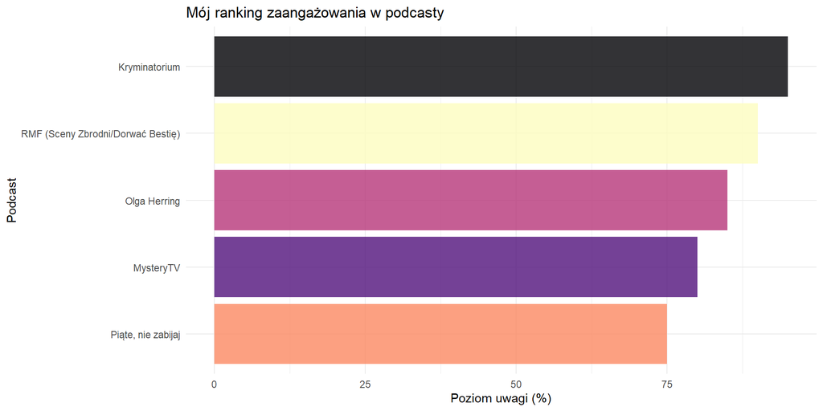

# Gry RPG: Ucieczka do Innych Światów

Gry fabularne to dla mnie sposób na przeżywanie niesamowitych przygód.

- **Wiedźmin**: Za klimat i słowiańskość.
- **The Elder Scrolls**: Za nieskończoną wolność eksploracji.
- **Where Winds Meet**: Moje najnowsze zainteresowanie światem open-world.

[figure not shown]

Wiedźmin

# Gry MMORPG: Albion Online

Mimo introwertyzmu, w świecie gier MMO odnajduję radość z interakcji społecznej.

- Przynależność do Gildii: To jedyny “eksces” towarzyski, który sprawia mi czystą przyjemność.
- Events: Wspólne wyprawy i walki o terytoria dają poczucie wspólnoty bez presji świata rzeczywistego.

[figure not shown]

Albion Online

# Literatura Fantasy i Young Adult

Książki to moja największa pasja. Uwielbiam serie, które budują rozbudowane uniwersa. *O to kilka z nich*:

| **Seria** | **Autor** |
| --- | --- |
| Wiedźmin | A. Sapkowski |
| Percy Jackson i Bogowie Olimpijscy | R. Riordan |
| Diabelskie Maszyny | C. Clare |
| Szklany Tron | S.J. Maas |

# Kultura Japonii: Anime i Manga

Interesuje mnie estetyka i sposób opowiadania historii w Japonii. Doceniam każdą scenę, która ukazuje kulturę i porusza ważne problemy społeczne, kulturowe lub moralne.

**Ulubiony gatunek**: *Isekai* (przeniesienie bohatera do innego świata – idealne dla marzycieli!).

**Co ceni?** *Kreatywność* w tworzeniu zasad magii i technologii.

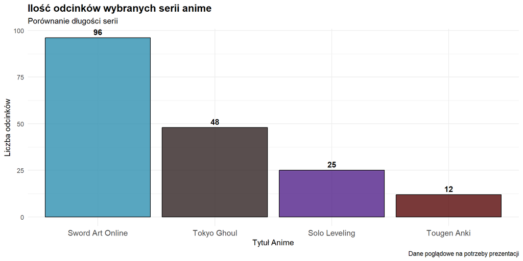

# Tak na koniec…

Pomimo moich “mrocznych” zainteresowań, jestem osobą ciepłą i uczuciową. Otaczam się wspaniałymi przyjaciółmi, z którymi mogę się rozwijać i dzielić swoimi zainteresowaniami.

**Ciekawostka**

Prawdpodobnie przez moje “poczucie odpowiedzialności” zostałam wybrana na satrostę roku na studiach.

# Dziękuję za uwagę!

[figure not shown]

zdjęcia są z gry Where Winds Meet